# Understanding genotype data

Population Genetics Practical 1: Allele coding, missing calls and phase

## Learning objectives

Read a genotype matrix; explain the counted allele and missing calls; align individuals and markers by identity; and distinguish unphased genotypes from haplotypes.

Use this practical alongside the slides on the genotype matrix and haplotypes and phase. You need basic Mendelian genetics and introductory R. The example uses base R and hypothetical data, with no downloads or package installation.

## 1. From two alleles to one dosage

At a diploid biallelic locus, each individual has two allele copies. Suppose the labels are A and B, and we choose **A as the counted allele**.

| Genotype | Copies of A | Copies of B |
| --- | --- | --- |
| AA | 2 | 0 |
| AB | 1 | 1 |
| BB | 0 | 2 |
| Unobserved | `NA` | `NA` |

A count of zero is an observed BB genotype. `NA` means the genotype is unknown. A and B name alleles; they do not establish dominance, causal effects or which allele is rarer.

**Question 1.** Can a value of 1 identify which parent transmitted A?

**Suggested answer**

No. A dosage of 1 describes a heterozygote. It carries no parental-origin information. At multiple loci, dosages also do not establish which alleles occur on the same chromosome.

## 2. Read a small genotype matrix

Rows identify individuals and columns identify loci. At `L1`, dosage counts A; at `L2`, dosage counts C. These are hypothetical marker labels, not physical genome positions.

**Show R code**

```r
M <- cbind(L1 = c(2L, 1L, NA_integer_, 0L, 1L, 2L),
           L2 = c(0L, 1L, 2L, 2L, NA_integer_, 1L))
rownames(M) <- paste0("individual", 1:6)
markers <- data.frame(marker=c("L1", "L2"),
                      counted_allele=c("A", "C"),
                      other_allele=c("B", "D"))
stopifnot(!anyDuplicated(rownames(M)), !anyDuplicated(colnames(M)),
          identical(colnames(M), markers$marker),
          all(M[!is.na(M)] %in% 0:2))
M
```

```
            L1 L2
individual1  2  0
individual2  1  1
individual3 NA  2
individual4  0  2
individual5  1 NA
individual6  2  1
```

**Show R code**

```r
markers
```

```
  marker counted_allele other_allele
1     L1              A            B
2     L2              C            D
```

**Question 2.** Interpret both entries for `individual2`. How many called genotypes are available at each marker?

**Show R code**

```r
M["individual2", ]
```

```
L1 L2
 1  1
```

**Show R code**

```r
data.frame(marker=colnames(M),
           called=colSums(!is.na(M)),
           missing=colSums(is.na(M)), row.names=NULL)
```

```
  marker called missing
1     L1      5       1
2     L2      5       1
```

**Suggested answer**

Individual 2 is AB at L1 and CD at L2. Each locus has five called individuals, but its missing call belongs to a different individual. A complete row is not required to summarize one locus; each locus has its own called denominator.

### Visualize the coding

**Show R code**

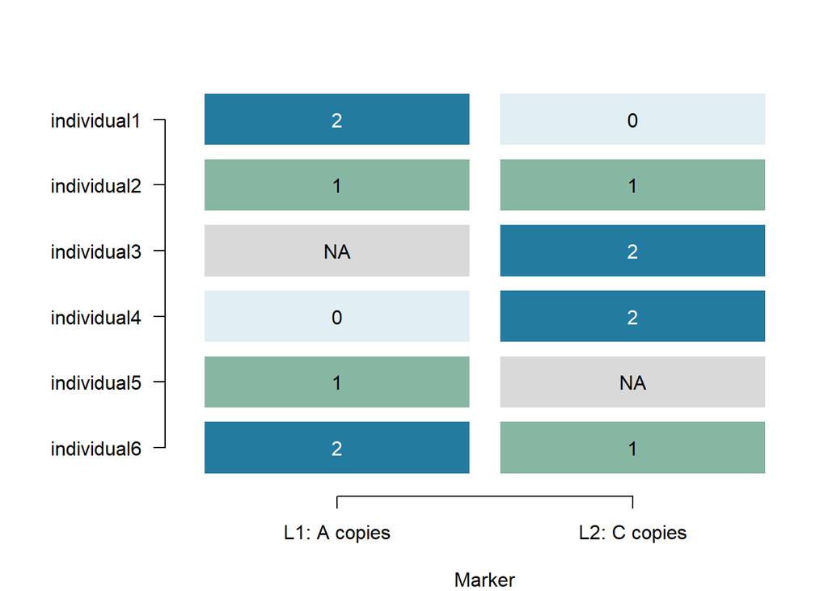

Figure 1: Called dosages at two hypothetical loci. Gray cells are missing calls; the counted allele differs between columns.

```r
local({
  old <- par(mar=c(4,7,3,1)); on.exit(par(old))
  plot(NA,xlim=c(0.5,2.5),ylim=c(0.5,6.5),xaxt="n",yaxt="n",
       xlab="Marker",ylab="",bty="n")
  axis(1,at=1:2,labels=c("L1: A copies","L2: C copies"))
  axis(2,at=6:1,labels=rownames(M),las=1)
  colors <- c("#E1EEF3", "#86B7A3", "#247BA0")
  for (i in 1:6) for (j in 1:2) {
    value <- M[i,j]
    fill <- if (is.na(value)) "#D9D9D9" else colors[value+1L]
    rect(j-0.45,7-i-0.4,j+0.45,7-i+0.4,col=fill,border="white")
    text(j,7-i,if(is.na(value)) "NA" else value,
         col=if(!is.na(value) && value==2) "white" else "black")
  }
})
```

This practical uses called integer genotypes. Fractional dosages can represent expected allele counts from imputation; they do not identify hard genotype classes without a separate calling rule. Polyploid, multiallelic or haploid data also need different contracts.

## 3. Keep identities and allele metadata aligned

Row positions are not identities. Suppose a phenotype table arrives in another order.

**Show R code**

```r
records <- data.frame(individual=c("individual4","individual1","individual6"),
                      hypothetical_trait=c(12,10,15))
position <- match(records$individual,rownames(M))
stopifnot(!anyNA(position), !anyDuplicated(records$individual))
aligned <- M[position,,drop=FALSE]
stopifnot(identical(rownames(aligned),records$individual))
cbind(records,aligned)
```

```
             individual hypothetical_trait L1 L2
individual4 individual4                 12  0  2
individual1 individual1                 10  2  0
individual6 individual6                 15  2  1
```

**Question 3.** Why would selecting the first three matrix rows be incorrect here?

**Suggested answer**

Those rows belong to individuals 1, 2 and 3, not the individuals listed in the records. Equal row counts do not guarantee a correct mapping. Marker metadata must similarly follow columns when they are reordered; physical positions and allele orientation cannot be inferred from matrix dimensions.

## 4. Reverse the counted allele

For diploid calls, B dosage is $2-$A dosage. Missing calls stay missing.

**Show R code**

```r
A_copies <- M[,"L1"]
B_copies <- 2L-A_copies
comparison <- data.frame(individual=rownames(M), A_copies, B_copies)
comparison
```

```
             individual A_copies B_copies
individual1 individual1        2        0
individual2 individual2        1        1
individual3 individual3       NA       NA
individual4 individual4        0        2
individual5 individual5        1        1
individual6 individual6        2        0
```

**Show R code**

```r
stopifnot(identical(is.na(A_copies),is.na(B_copies)),
          all((A_copies+B_copies)[!is.na(A_copies)]==2))
```

**Question 4.** Does changing the counted allele change the underlying individuals or their heterozygosity?

**Suggested answer**

No. The two homozygote labels exchange roles and heterozygotes remain heterozygotes. The reported counted-allele frequency changes to its complement. Always state the counted allele with a result; numeric dosages alone do not establish allele identity.

## 5. Distinguish genotype from haplotype phase

Individual 2 is heterozygous at both loci. Two possible chromosome pairs are

| Phase configuration | Chromosome 1 | Chromosome 2 |
| --- | --- | --- |
| Coupling | A–C | B–D |
| Repulsion | A–D | B–C |

Both produce one A copy and one C copy, so both have the same unphased row `(1,1)`.

**Show R code**

```r
coupling <- rbind(c("A","C"),c("B","D"))
repulsion <- rbind(c("A","D"),c("B","C"))
counted <- c("A","C")
phase_dosage <- function(chromosomes) {
  vapply(1:2,function(j) sum(chromosomes[,j]==counted[j]),integer(1))
}
rbind(coupling=phase_dosage(coupling), repulsion=phase_dosage(repulsion))
```

```
          [,1] [,2]
coupling     1    1
repulsion    1    1
```

**Show R code**

```r
stopifnot(identical(phase_dosage(coupling),phase_dosage(repulsion)))
```

**Question 5.** Can the matrix tell us whether individual 2 carries the A–C haplotype?

**Suggested answer**

No. Phase information or a declared inference method is required. Frequencies of unphased allele counts are observed summaries; haplotype frequencies cannot be read directly from those counts. Dosage correlation should not automatically be called haplotype linkage disequilibrium.

## Exercises

1. Decode all called L1 entries as AA, AB or BB.
2. Reorder the marker columns and align their metadata by marker identity.
3. Replace the missing L1 call with zero. Explain why this changes the biological information rather than only the display.

**Suggested solutions**

**Show R code**

```r
labels <- c("BB","AB","AA")
decoded <- rep(NA_character_,length(A_copies))
decoded[!is.na(A_copies)] <- labels[A_copies[!is.na(A_copies)]+1L]
data.frame(individual=rownames(M),genotype=decoded)
```

```
   individual genotype
1 individual1       AA
2 individual2       AB
3 individual3     <NA>
4 individual4       BB
5 individual5       AB
6 individual6       AA
```

**Show R code**

```r
reordered <- M[,c("L2","L1"),drop=FALSE]
metadata_reordered <- markers[match(colnames(reordered),markers$marker),]
stopifnot(identical(colnames(reordered),metadata_reordered$marker))
metadata_reordered
```

```
  marker counted_allele other_allele
2     L2              C            D
1     L1              A            B
```

Replacing `NA` with zero asserts a known BB genotype. It adds two observed B allele copies and changes called denominators. Such a change needs a justified imputation/calling procedure, not a display preference.

## Next practical and package connection

Practical 2 calculates allele/genotype frequencies and compares them with Hardy–Weinberg expectations. `gpop` owns population summaries and expectations; its current [teaching examples](https://github.com/psoerensen/gpop/tree/main/inst/examples) are base-R calculations, with scientific APIs still proposed. Biological genotype simulation belongs in `gsim`.